# CRISPR screening - R practice

In this notebook, we will introdcue a few R packages that can be handy to manipulate, summarize and plot the data coming from the PinAPL-py pipeline. Importantly, the methodlogies presented here can be applied and expanded to any reasonnably sized dataset.

In order to best benefit form this practise and use case. One needs to be familiar with R data structure and maniulation, mostly differentating vector, matrix and dataframes. A primer on the different data types (numeric, integer, character, etc) is also useful.

## Data Import and Formatting

The pipeline places the count data in different folders. While there is a way to have R crawl through mulitple folders and import the data, we will assume here, for convenience, that the counts files have been placed in the same folder and renamed after the library ID. We will import the non-normalized counts.

Fiorst we write a functions that takes the file name (and path), import the content into a dataframe, names the columns, and add a column containing the name of the file.

```r
importCounts<-function(x){
  f<-read.delim(x,header=FALSE)
  colnames(f)<-c("sgRNA","gene", "value")
  f$Library<-x
  return(f)
}
```

Now we apply this function to a list of files in the folder.

```r
files <- list.files(path="./counts",pattern=".tsv",full.names = TRUE)
CountSg<-sapply(files,importCounts,simplify=FALSE)
```

We get a list of dataframes, which we collapse into one giant dataframes to which we remove the rownames, since they ar enot relevant.

```r
CountSg<-do.call(rbind,CountSg)
rownames(CountSg)<-NULL
```

We can now edit the dataframe and separate the library field into subfields using the function tidyr::separate function

```r
CountSg<-separate(CountSg, Library, sep="[./]",into=c("pre1","pre2","folder","Library","ext1","ext2"),remove=TRUE)
```

and we keep only the column we care about using dplyr::select

```r
CountSg<-select(CountSg,sgRNA,gene,value,Library)
```

We have now a large dataframe containing all the counts data

## Summary Statistics and Normalization

Here we will use mostly functions from the dplyr package. for example to determine the total number of counts in each library

```r
totalCounts<-CountSg %>% group_by(Library) %>% summarize(Total=sum(value))
totalCounts
```

| Library | Total |
| --- | --- |
| I1R1T0_1 | 15679914 |
| I1R1T3_T | 7552567 |
| I1R1T3_U | 18449501 |
| I1R2T0_1 | 14116155 |
| I1R2T3_T | 7253390 |
| I1R2T3_U | 15109877 |
| I2R1T0_1 | 17376475 |
| I2R1T3_T | 16900882 |
| I2R1T3_U | 15423642 |
| I2R2T0_1 | 15129315 |

[output cut: 2 more lines]

We can therefore normalized the counts to the total number of counts in each library and multiply by 1E6 to get an RPM (read per million) unit. For this we can use the function dplyr::mutate, which can assign tghe results of an operation to a new column. But before we specigy the grouping variable.

```r
CountSg<-CountSg %>% group_by(Library) %>% mutate(RPM=value*1E6/sum(value))
```

We can now verify that all the libraries have the same sum of RPM and can be compared

```r
CountSg %>% group_by(Library) %>% summarize(Total=sum(RPM))
```

| Library | Total |
| --- | --- |
| I1R1T0_1 | 1e+06 |
| I1R1T3_T | 1e+06 |
| I1R1T3_U | 1e+06 |
| I1R2T0_1 | 1e+06 |
| I1R2T3_T | 1e+06 |
| I1R2T3_U | 1e+06 |
| I2R1T0_1 | 1e+06 |
| I2R1T3_T | 1e+06 |
| I2R1T3_U | 1e+06 |
| I2R2T0_1 | 1e+06 |

[output cut: 2 more lines]

# plotting cumulative distribution

Let’s now look at the distribution of RPM in each library. For this, we can use the ggplot2 package to plot the cumulative distribution function. Which is similar to the Lorenz plot generated by PinAPL-Py. Let’s start with one library.

let’s start with one library using the dplyr::filter command

```r
C1<-filter(CountSg,Library=="Control_1")
```

A typical ggplot command starts with the `ggplot` fucntion, which specifies the dataframe and the variable to use in the “aesthetic” (x, y, colors, sizes, etc, etc). This function is them modified by adding the type of plot desired, here stat_ecdf(). The RPM values are following an exponential distribution (lots of low covered sgRNA), we will therefore plot their log10. In order to also represent the sgRNA that are not covered in the library (RPM=0), we will add a small number to all RPM. Finally, we specific the size of the plot (in inches) in the header.

[figure not shown]

```r
ggplot(C1,aes(log10(RPM+0.01)))+stat_ecdf()
```

We can now change a bit the labels and the size of the font to make it prettier

[figure not shown]

```r
ggplot(C1,aes(log10(RPM+0.01)))+stat_ecdf()+
  ylab("Fraction of sgRNA")+
  xlab("log10(RPM)")+
  theme(text=element_text(size=20))
```

and now we can plot all libraies on the same plot, by starting from the full datafrane and adding a color variable to the aesthetic, (adn adjusting the)and adjusting panel wiodth to make room for the legend)

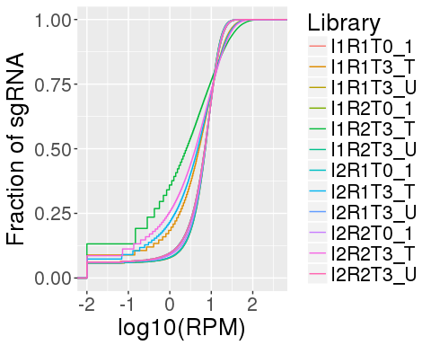

```r
ggplot(CountSg,aes(log10(RPM+0.01),col=Library))+stat_ecdf()+
  ylab("Fraction of sgRNA")+
  xlab("log10(RPM)")+
  theme(text=element_text(size=20))
```

Now, this is too many libraries to visualize on one plot, we shoudl be able to separate them by timepoint and condition. We need to add another field to the dataframe. For this we will use the function dplyr::mutate seen before and perfrom a logical test based on the name of the library using grepl. grepl returns TRUE if the queries string is present in the tested string, FALSE otherwise. The function `ifelse` will assign the type to the type variable, as a result of this test.

```r
CountSg<-mutate(CountSg,type=ifelse(grepl("T0",Library),"Baseline","T3"))
CountSg<-mutate(CountSg,type=ifelse(grepl("T3_T",Library),"treated_T3",type))
CountSg<-mutate(CountSg,type=ifelse(grepl("T3_U",Library),"untreated_T3",type))
```

we can verify the new field, by listing the unique columns

```r
CountSg %>% select(Library,type) %>% unique()
```

| Library | type |
| --- | --- |
| I1R1T0_1 | Baseline |
| I1R1T3_T | treated_T3 |
| I1R1T3_U | untreated_T3 |
| I1R2T0_1 | Baseline |
| I1R2T3_T | treated_T3 |
| I1R2T3_U | untreated_T3 |
| I2R1T0_1 | Baseline |
| I2R1T3_T | treated_T3 |
| I2R1T3_U | untreated_T3 |
| I2R2T0_1 | Baseline |

[output cut: 2 more lines]

and we can now use the fucntion facet_wrap in ggplot to separate each type on a separate panel, increaseing the width (resp heigth) to make room if we display them in a row (resp. column)

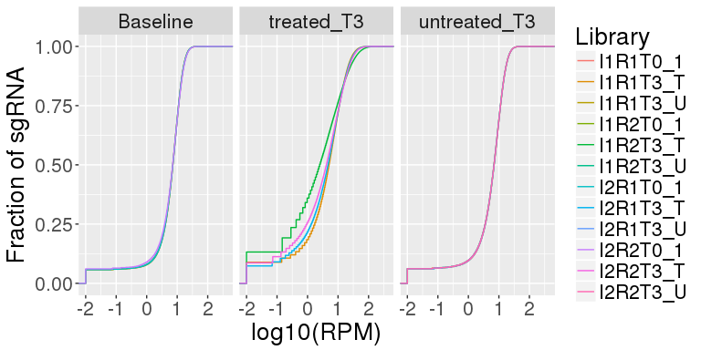

```r
ggplot(CountSg,aes(log10(RPM+0.01),col=Library))+stat_ecdf()+
  ylab("Fraction of sgRNA")+
  xlab("log10(RPM)")+
  theme(text=element_text(size=20))+
  facet_wrap(~type,ncol=3)
```

We can clearly see that some selection happened in the treated sample. Let’s calculte the gini coefficient for each library. this is provided by the function ineq::ineq

```r
gini<-CountSg %>% group_by(Library,type) %>% summarize(gini=ineq(RPM,type="Gini"))
gini
```

| Library | type | gini |
| --- | --- | --- |
| I1R1T0_1 | Baseline | 0.3810707 |
| I1R1T3_T | treated_T3 | 0.5591282 |
| I1R1T3_U | untreated_T3 | 0.4152534 |
| I1R2T0_1 | Baseline | 0.3816828 |
| I1R2T3_T | treated_T3 | 0.7085191 |
| I1R2T3_U | untreated_T3 | 0.4162315 |
| I2R1T0_1 | Baseline | 0.3818141 |
| I2R1T3_T | treated_T3 | 0.5865197 |
| I2R1T3_U | untreated_T3 | 0.4151149 |
| I2R2T0_1 | Baseline | 0.3964067 |

[output cut: 2 more lines]

Let’s plot the corresponding bar graph using the geom_bar function. Beause the value to plot is directly given by the gini field and that no math or calculations are needed, we need to specific stat=“identity”

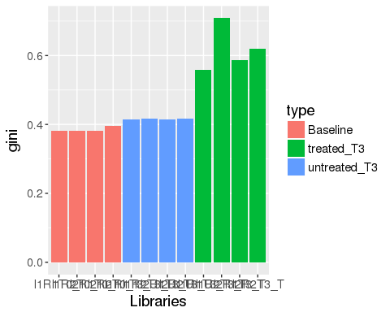

```r
ggplot(gini,aes(Library,gini,fill=type))+geom_bar(stat="identity")+
 ylab("gini")+
  xlab("Libraries")+
  theme(text=element_text(size=14))
```

Now this is not pretty, we can rotate the x axis labels in the theme variable. But before we need to change the levels of the Name and type variable so that they are not plotted in alphabetical order.

```r
gini$Library<-factor(gini$Library,levels=c("I1R1T0_1","I1R2T0_1","I2R1T0_1","I2R2T0_1","I1R1T3_U","I1R2T3_U","I2R1T3_U","I2R2T3_U","I1R1T3_T","I1R2T3_T","I2R1T3_T","I2R2T3_T"))
```

Now we can replot, rotatign the x axiss

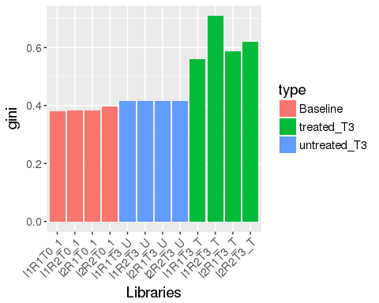

```r
ggplot(gini,aes(Library,gini,fill=type))+geom_bar(stat="identity")+
 ylab("gini")+
  xlab("Libraries")+
  theme(text=element_text(size=14),axis.text.x=element_text(angle=45,hjust=1))
```

## dplyr

the dplyr package is essential to manipulate and summarize dataframe. The main function will be ‘select’, ‘filter’ and ‘left_join’. Additional function such as ‘top_n’ are also handy. The piping feature ‘%>%’ will allow you to stich commands sequentially for increase lisibility.

let’s load the package

```r
library(dplyr)
```

## reshape2

The reshape package has pretty much two function that are really handy: ‘dcast’ and ‘melt’. They allow you to conert betwween wide (matrix-like) and long (flat) formats.

## pheatmap

This package is the most versatile to make nice looking heatmap, including annotation columns. It requires you to format the data into a matrix (no dataframes!). If you want to annotate columns or rows, you need to prepare separate matrices, with rownames matching what you want to annotate. Customizing colors is a bit more involved, but doable.

## ggplot2

# resources

I enjoy the blog from Steven Turner, which provides great example of R/bioconductor applied to genomics.

Finally, there are a number of chearsheet, that you may want to keep close to you. dplyr ggplot Rcolorbrewer